# Tugas Praktikum 1 Metode Peramalan Deret Waktu

G1401211066_Oktavia Galih Pratiwi

2023-09-02

## Memanggil Library

```r
library("forecast")
```

```r
library("graphics")
library("TTR")
library("TSA")
library(rio)
library(ggplot2)
```

## Mengimpor data Europe Brent Spot Price FOB Dollars per Barrel

```r
databrentprice <- import("https://raw.githubusercontent.com/oktaviagalihpratiwi/praktikum-mpdwokta/main/Data/data_brentprice.csv")
databrentprice
```

```
##         Period  Price
## 1   01/01/2000  25.51
## 2   01/02/2000  27.78
## 3   01/03/2000  27.49
## 4   01/04/2000  22.76
## 5   01/05/2000  27.74
## 6   01/06/2000  29.80
## 7   01/07/2000  28.68
## 8   01/08/2000  30.20
## 9   01/09/2000  33.14
## 10  01/10/2000  30.96
## 11  01/11/2000  32.55
## 12  01/12/2000  25.66
## 13  01/01/2001  25.62
## 14  01/02/2001  27.50
```

[output cut: 269 more lines]

## Eksplorasi Data

Melihat data menggunakan fungsi `View()`, struktur data menggunakan fungsi `str()`, dan dimensi data menggunakan fungsi `dim()`.

```r
View(databrentprice)
str(databrentprice)
```

```
## 'data.frame':    283 obs. of  2 variables:
##  $ Period: chr  "01/01/2000" "01/02/2000" "01/03/2000" "01/04/2000" ...
##  $ Price : num  25.5 27.8 27.5 22.8 27.7 ...
```

```r
dim(databrentprice)
```

```
## [1] 283   2
```

## Mengubah data agar terbaca sebagai data deret waktu dengan fungsi `ts()`

```r
databrentprice.ts <- ts(databrentprice$Price)
databrentprice.ts
```

```
## Time Series:
## Start = 1
## End = 283
## Frequency = 1
##   [1]  25.51  27.78  27.49  22.76  27.74  29.80  28.68  30.20  33.14  30.96
##  [11]  32.55  25.66  25.62  27.50  24.50  25.66  28.31  27.85  24.61  25.68
##  [21]  25.62  20.54  18.80  18.71  19.42  20.28  23.70  25.73  25.35  24.08
##  [31]  25.74  26.65  28.40  27.54  24.34  28.33  31.18  32.77  30.61  25.00
##  [41]  25.86  27.65  28.35  29.89  27.11  29.61  28.75  29.81  31.28  30.86
##  [51]  33.63  33.59  37.57  35.18  38.22  42.74  43.20  49.78  43.11  39.60
##  [61]  44.51  45.48  53.10  51.88  48.65  54.35  57.52  63.98  62.91  58.54
##  [71]  55.24  56.86  62.99  60.21  62.06  70.26  69.78  68.56  73.67  73.23
##  [81]  61.96  57.81  58.76  62.47  53.68  57.56  62.05  67.49  67.21  71.05
##  [91]  76.93  70.76  77.17  82.34  92.41  90.93  92.18  94.99 103.64 109.07
## [101] 122.80 132.32 132.72 113.24  97.23  71.58  52.45  39.95  43.44  43.32
```

[output cut: 18 more lines]

## Menampilkan ringkasan data

```r
summary(databrentprice.ts)
```

```
##    Min. 1st Qu.  Median    Mean 3rd Qu.    Max.
##   18.38   43.16   63.21   65.76   84.73  132.72
```

## Membuat plot data deret waktu

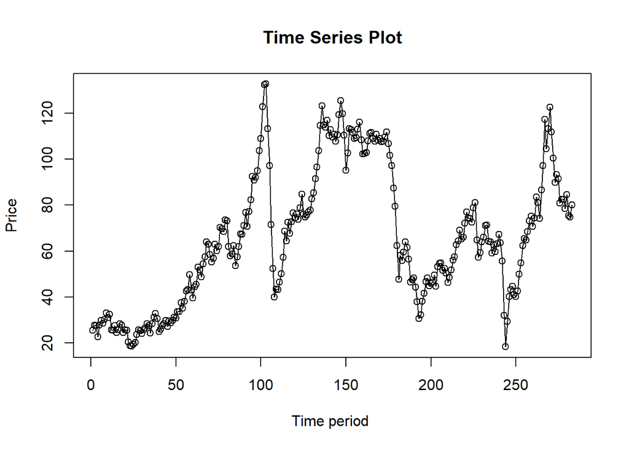

```r
ts.plot(databrentprice.ts, xlab="Time period ", ylab="Price",
        main = "Time Series Plot")
points(databrentprice.ts)
```

## Single Moving Average

### Pembagian Data

Pembagian data latih dan data uji dilakukan dengan perbandingan 80% data latih dan 20% data uji.

```r
#membagi data latih dan data uji
training_brent <- databrentprice[1:227,]
testing_brent <- databrentprice[228:283,]
train_brent.ts <- ts(training_brent$Price)
test_brent.ts <- ts(testing_brent$Price)
```

### Eksplorasi Data

Eksplorasi data dilakukan pada keseluruhan data, data latih serta data uji menggunakan plot data deret waktu.

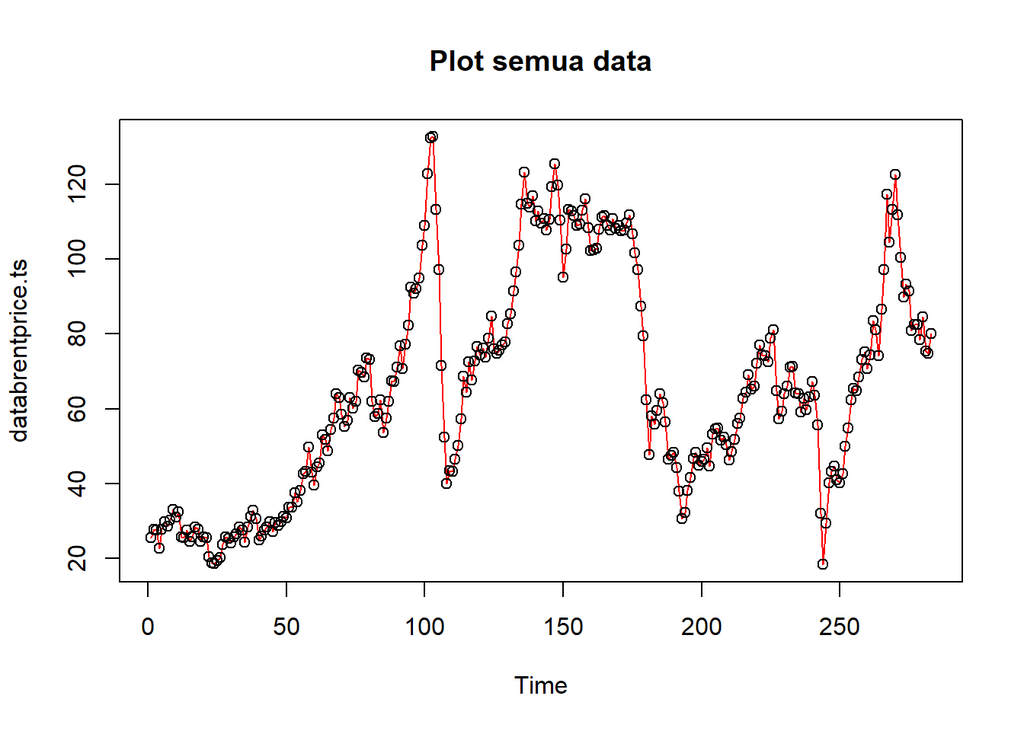

```r
#Eksplorasi keseluruhan data
plot(databrentprice.ts, col="red",main="Plot semua data")
points(databrentprice.ts)
```

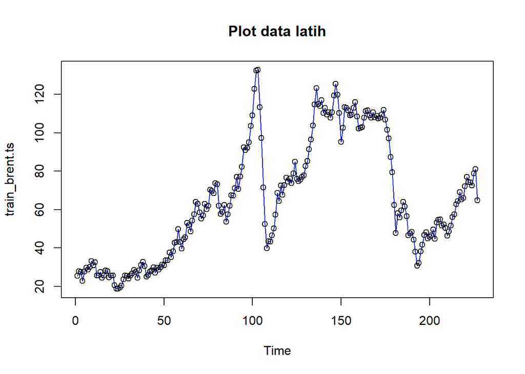

```r
#Eksplorasi data latih
plot(train_brent.ts, col="blue",main="Plot data latih")
points(train_brent.ts)
```

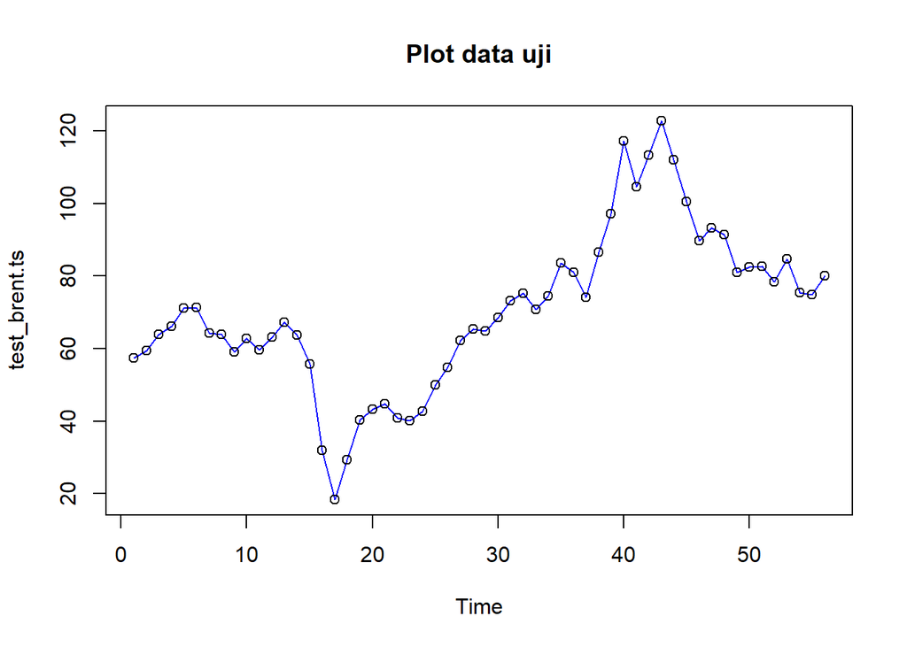

```r
#Eksplorasi data uji
plot(test_brent.ts, col="blue",main="Plot data uji")
points(test_brent.ts)
```

```r
data.sma<-SMA(train_brent.ts, n=4)
data.sma
```

```
## Time Series:
## Start = 1
## End = 227
## Frequency = 1
##   [1]       NA       NA       NA  25.8850  26.4425  26.9475  27.2450  29.1050
##   [9]  30.4550  30.7450  31.7125  30.5775  28.6975  27.8325  25.8200  25.8200
##  [17]  26.4925  26.5800  26.6075  26.6125  25.9400  24.1125  22.6600  20.9175
##  [25]  19.3675  19.3025  20.5275  22.2825  23.7650  24.7150  25.2250  25.4550
##  [33]  26.2175  27.0825  26.7325  27.1525  27.8475  29.1550  30.7225  29.8900
##  [41]  28.5600  27.2800  26.7150  27.9375  28.2500  28.7400  28.8400  28.8200
##  [49]  29.8625  30.1750  31.3950  32.3400  33.9125  34.9925  36.1400  38.4275
##  [57]  39.8350  43.4850  44.7075  43.9225  44.2500  43.1750  45.6725  48.7425
##  [65]  49.7775  51.9950  53.1000  56.1250  59.6900  60.7375  60.1675  58.3875
##  [73]  58.4075  58.8250  60.5300  63.8800  65.5775  67.6650  70.5675  71.3100
##  [81]  69.3550  66.6675  62.9400  60.2500  58.1800  58.1175  58.9400  60.1950
```

[output cut: 18 more lines]

```r
data.ramal<-c(NA,data.sma)
data.ramal #forecast 1 periode ke depan
```

```
##   [1]       NA       NA       NA       NA  25.8850  26.4425  26.9475  27.2450
##   [9]  29.1050  30.4550  30.7450  31.7125  30.5775  28.6975  27.8325  25.8200
##  [17]  25.8200  26.4925  26.5800  26.6075  26.6125  25.9400  24.1125  22.6600
##  [25]  20.9175  19.3675  19.3025  20.5275  22.2825  23.7650  24.7150  25.2250
##  [33]  25.4550  26.2175  27.0825  26.7325  27.1525  27.8475  29.1550  30.7225
##  [41]  29.8900  28.5600  27.2800  26.7150  27.9375  28.2500  28.7400  28.8400
##  [49]  28.8200  29.8625  30.1750  31.3950  32.3400  33.9125  34.9925  36.1400
##  [57]  38.4275  39.8350  43.4850  44.7075  43.9225  44.2500  43.1750  45.6725
##  [65]  48.7425  49.7775  51.9950  53.1000  56.1250  59.6900  60.7375  60.1675
##  [73]  58.3875  58.4075  58.8250  60.5300  63.8800  65.5775  67.6650  70.5675
##  [81]  71.3100  69.3550  66.6675  62.9400  60.2500  58.1800  58.1175  58.9400
##  [89]  60.1950  63.5775  66.9500  70.6700  71.4875  73.9775  76.8000  80.6700
##  [97]  85.7125  89.4650  92.6275  95.4350  99.9700 107.6250 116.9575 124.2275
## [105] 125.2700 118.8775 103.6925  83.6250  65.3025  51.8550  44.7900  43.3125
## [113]  45.8700  49.3350  55.6575  60.1325  65.7150  68.3025  69.3425  72.3975
## [121]  72.8850  75.0150  75.2600  75.8025  78.3925  78.3375  78.5900  77.7775
## [129]  75.8325  76.3050  78.2825  80.7075  84.3100  88.9800  94.2425 101.5825
## [137] 109.5350 114.1525 116.6800 117.2625 114.0025 113.4625 112.3925 110.8425
## [145] 110.2550 109.7200 112.1650 115.8350 118.8050 118.7175 112.6750 106.9675
## [153] 105.3700 106.0000 110.1375 111.7475 110.7800 110.8050 111.8900 111.7425
## [161] 109.9325 107.3325 104.0500 103.9150 106.1725 108.4325 109.9725 109.9375
## [169] 109.8075 108.9375 108.8925 108.8150 108.0650 108.4200 109.1450 108.9675
## [177] 107.4300 104.3175  98.2250  91.3925  81.5750  69.2425  61.9100  56.0225
## [185]  55.3175  59.3975  60.2425  60.4100  57.1600  53.0450  49.7825  46.7100
## [193]  44.5825  40.3525  36.2900  34.7750  35.6675  39.6775  43.6950  45.3800
## [201]  46.4450  46.4025  46.7200  46.6650  48.5325  50.5350  51.8725  53.5875
## [209]  53.3375  52.2750  50.1500  49.3725  49.2200  50.6750  53.4600  57.0175
## [217]  60.1850  63.4175  65.3700  66.1975  68.1325  70.1075  72.3800  74.4375
## [225]  74.5425  75.0200  76.6750  74.3000
```

```r
data.gab<-cbind(aktual=c(train_brent.ts,rep(NA,56)),pemulusan=c(data.sma,rep(NA,56)),ramalan=c(data.ramal,rep(data.ramal[length(data.ramal)],55)))
data.gab #forecast 56 periode ke depan
```

```
##        aktual pemulusan  ramalan
##   [1,]  25.51        NA       NA
##   [2,]  27.78        NA       NA
##   [3,]  27.49        NA       NA
##   [4,]  22.76   25.8850       NA
##   [5,]  27.74   26.4425  25.8850
##   [6,]  29.80   26.9475  26.4425
##   [7,]  28.68   27.2450  26.9475
##   [8,]  30.20   29.1050  27.2450
##   [9,]  33.14   30.4550  29.1050
##  [10,]  30.96   30.7450  30.4550
##  [11,]  32.55   31.7125  30.7450
##  [12,]  25.66   30.5775  31.7125
##  [13,]  25.62   28.6975  30.5775
##  [14,]  27.50   27.8325  28.6975
```

[output cut: 269 more lines]

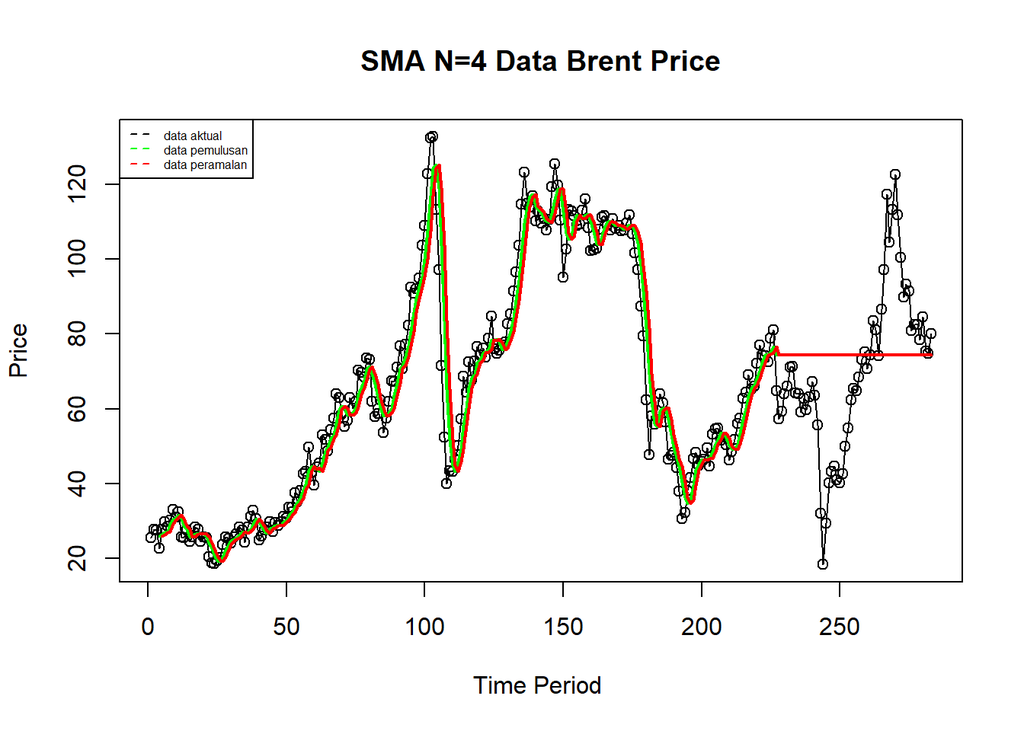

```r
ts.plot(databrentprice.ts, xlab="Time Period ", ylab="Price", main= "SMA N=4 Data Brent Price")
points(databrentprice.ts)
lines(data.gab[,2],col="green",lwd=2)
lines(data.gab[,3],col="red",lwd=2)
legend("topleft",c("data aktual","data pemulusan","data peramalan"), lty=8, col=c("black","green","red"), cex=0.5)
```

```r
#Menghitung nilai keakuratan data latih
error_train.sma = train_brent.ts-data.ramal[1:length(train_brent.ts)]
SSE_train.sma = sum(error_train.sma[5:length(train_brent.ts)]^2)
MSE_train.sma = mean(error_train.sma[5:length(train_brent.ts)]^2)
MAPE_train.sma = mean(abs((error_train.sma[5:length(train_brent.ts)]/train_brent.ts[5:length(train_brent.ts)])*100))

akurasi_train.sma <- matrix(c(SSE_train.sma, MSE_train.sma, MAPE_train.sma))
row.names(akurasi_train.sma)<- c("SSE", "MSE", "MAPE")
colnames(akurasi_train.sma) <- c("Akurasi m = 4")
akurasi_train.sma
```

```
##      Akurasi m = 4
## SSE    21170.19281
## MSE       94.93360
## MAPE      10.75967
```

Perhitungan akurasi menggunakan data latih dengan metode single double moving average sebesar 10.76% sehingga nilai akurasi ini dapat dikategorikan sebagai baik.

```r
#Menghitung nilai keakuratan data uji
error_test.sma = test_brent.ts-data.gab[228:283,3]
SSE_test.sma = sum(error_test.sma^2)
MSE_test.sma = mean(error_test.sma^2)
MAPE_test.sma = mean(abs((error_test.sma/test_brent.ts*100)))

akurasi_test.sma <- matrix(c(SSE_test.sma, MSE_test.sma, MAPE_test.sma))
row.names(akurasi_test.sma)<- c("SSE", "MSE", "MAPE")
colnames(akurasi_test.sma) <- c("Akurasi m = 4")
akurasi_test.sma
```

```
##      Akurasi m = 4
## SSE    27424.98330
## MSE      489.73184
## MAPE      32.82956
```

Perhitungan akurasi menggunakan data uji dengan metode single moving average sebesar32.8% sehingga nilai akurasi ini dapat dikategorikan sebagai layak.

## Double Moving Average (DMA)

```r
dma <- SMA(data.sma, n = 4)
At <- 2*data.sma - dma
Bt <- 2/(4-1)*(data.sma - dma)
data.dma<- At+Bt
data.ramal2<- c(NA, data.dma)

t = 1:56
f = c()

for (i in t) {
  f[i] = At[length(At)] + Bt[length(Bt)]*(i)
}

data.gab2 <- cbind(aktual = c(train_brent.ts,rep(NA,56)), pemulusan1 = c(data.sma,rep(NA,56)),pemulusan2 = c(data.dma, rep(NA,56)),At = c(At, rep(NA,56)), Bt = c(Bt,rep(NA,56)),ramalan = c(data.ramal2, f[-1]))
data.gab2
```

```
##        aktual pemulusan1 pemulusan2        At            Bt   ramalan
##   [1,]  25.51         NA         NA        NA            NA        NA
##   [2,]  27.78         NA         NA        NA            NA        NA
##   [3,]  27.49         NA         NA        NA            NA        NA
##   [4,]  22.76    25.8850         NA        NA            NA        NA
##   [5,]  27.74    26.4425         NA        NA            NA        NA
##   [6,]  29.80    26.9475         NA        NA            NA        NA
##   [7,]  28.68    27.2450   28.27000  27.86000  4.100000e-01        NA
##   [8,]  30.20    29.1050   31.88833  30.77500  1.113333e+00  28.27000
##   [9,]  33.14    30.4550   33.81646  32.47188  1.344583e+00  31.88833
##  [10,]  30.96    30.7450   33.00750  32.10250  9.050000e-01  33.81646
##  [11,]  32.55    31.7125   33.72604  32.92062  8.054167e-01  33.00750
##  [12,]  25.66    30.5775   30.08583  30.28250 -1.966667e-01  33.72604
##  [13,]  25.62    28.6975   25.80479  26.96187 -1.157083e+00  30.08583
##  [14,]  27.50    27.8325   24.71167  25.96000 -1.248333e+00  25.80479
```

[output cut: 269 more lines]

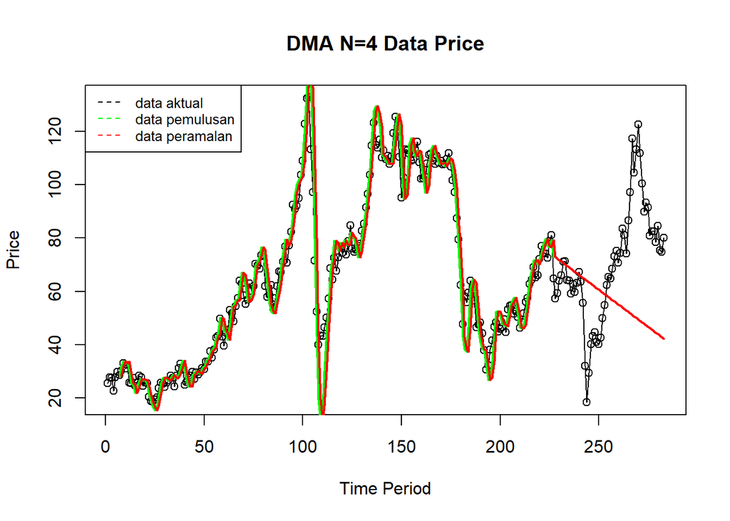

```r
ts.plot(databrentprice.ts, xlab="Time Period", ylab="Price", main= "DMA N=4 Data Price")
points(databrentprice.ts)
lines(data.gab2[,3],col="green",lwd=2)
lines(data.gab2[,6],col="red",lwd=2)
legend("topleft",c("data aktual","data pemulusan","data peramalan"), lty=8, col=c("black","green","red"), cex=0.8)
```

```r
#Menghitung nilai keakuratan data latih
error_train.dma = train_brent.ts-data.ramal2[1:length(train_brent.ts)]
SSE_train.dma = sum(error_train.dma[8:length(train_brent.ts)]^2)
MSE_train.dma = mean(error_train.dma[8:length(train_brent.ts)]^2)
MAPE_train.dma = mean(abs((error_train.dma[8:length(train_brent.ts)]/train_brent.ts[8:length(train_brent.ts)])*100))

akurasi_train.dma <- matrix(c(SSE_train.dma, MSE_train.dma, MAPE_train.dma))
row.names(akurasi_train.dma)<- c("SSE", "MSE", "MAPE")
colnames(akurasi_train.dma) <- c("Akurasi m = 4")
akurasi_train.dma
```

```
##      Akurasi m = 4
## SSE    18570.00814
## MSE       84.40913
## MAPE      10.53020
```

Perhitungan akurasi menggunakan data latih dengan metode double moving average sebesar 10.53% sehingga nilai akurasi ini dapat dikategorikan sebagai baik.

```r
#Menghitung nilai keakuratan data uji
error_test.dma = test_brent.ts-data.gab2[228:283,6]
SSE_test.dma = sum(error_test.dma^2)
MSE_test.dma = mean(error_test.dma^2)
MAPE_test.dma = mean(abs((error_test.dma/test_brent.ts*100)))

akurasi_test.dma <- matrix(c(SSE_test.dma, MSE_test.dma, MAPE_test.dma))
row.names(akurasi_test.dma)<- c("SSE", "MSE", "MAPE")
colnames(akurasi_test.dma) <- c("Akurasi m = 4")
akurasi_test.dma
```

```
##      Akurasi m = 4
## SSE    53835.95997
## MSE      961.35643
## MAPE      37.24784
```

Perhitungan akurasi menggunakan data uji dengan metode double moving average sebesar 37.24% sehingga nilai akurasi ini dapat dikategorikan sebagai cukup baik (layak).

Pada data latih, metode DMA lebih baik dibandingkan dengan metode SMA, tetapi tidak terlalu beda secara signifikan. Sementara itu, pada data uji metode SMA lebih baik dibandingkan DMA.

## Single Exponential Smoothing & Double Exponential Smoothing

Metode *Exponential Smoothing* adalah metode pemulusan dengan melakukan pembobotan menurun secara eksponensial. Nilai yang lebih baru diberi bobot yang lebih besar dari nilai terdahulu. Terdapat satu atau lebih parameter pemulusan yang ditentukan secara eksplisit, dan hasil pemilihan parameter tersebut akan menentukan bobot yang akan diberikan pada nilai pengamatan. Ada dua macam model, yaitu model tunggal dan ganda.

Pembagian data latih dan data uji dilakukan dengan perbandingan 80% data latih dan 20% data uji.

```r
#membagi training dan testing
training <- databrentprice[1:227,]
training
```

```
##         Period  Price
## 1   01/01/2000  25.51
## 2   01/02/2000  27.78
## 3   01/03/2000  27.49
## 4   01/04/2000  22.76
## 5   01/05/2000  27.74
## 6   01/06/2000  29.80
## 7   01/07/2000  28.68
## 8   01/08/2000  30.20
## 9   01/09/2000  33.14
## 10  01/10/2000  30.96
## 11  01/11/2000  32.55
## 12  01/12/2000  25.66
## 13  01/01/2001  25.62
## 14  01/02/2001  27.50
```

[output cut: 213 more lines]

```r
testing <- databrentprice[228:283,]
testing
```

```
##         Period  Price
## 228 01/12/2018  57.36
## 229 01/01/2019  59.41
## 230 01/02/2019  63.96
## 231 01/03/2019  66.14
## 232 01/04/2019  71.23
## 233 01/05/2019  71.32
## 234 01/06/2019  64.22
## 235 01/07/2019  63.92
## 236 01/08/2019  59.04
## 237 01/09/2019  62.83
## 238 01/10/2019  59.71
## 239 01/11/2019  63.21
## 240 01/12/2019  67.31
## 241 01/01/2020  63.65
```

[output cut: 42 more lines]

```r
train.ts <- ts(training$Price)
train.ts
```

```
## Time Series:
## Start = 1
## End = 227
## Frequency = 1
##   [1]  25.51  27.78  27.49  22.76  27.74  29.80  28.68  30.20  33.14  30.96
##  [11]  32.55  25.66  25.62  27.50  24.50  25.66  28.31  27.85  24.61  25.68
##  [21]  25.62  20.54  18.80  18.71  19.42  20.28  23.70  25.73  25.35  24.08
##  [31]  25.74  26.65  28.40  27.54  24.34  28.33  31.18  32.77  30.61  25.00
##  [41]  25.86  27.65  28.35  29.89  27.11  29.61  28.75  29.81  31.28  30.86
##  [51]  33.63  33.59  37.57  35.18  38.22  42.74  43.20  49.78  43.11  39.60
##  [61]  44.51  45.48  53.10  51.88  48.65  54.35  57.52  63.98  62.91  58.54
##  [71]  55.24  56.86  62.99  60.21  62.06  70.26  69.78  68.56  73.67  73.23
##  [81]  61.96  57.81  58.76  62.47  53.68  57.56  62.05  67.49  67.21  71.05
##  [91]  76.93  70.76  77.17  82.34  92.41  90.93  92.18  94.99 103.64 109.07
## [101] 122.80 132.32 132.72 113.24  97.23  71.58  52.45  39.95  43.44  43.32
## [111]  46.54  50.18  57.30  68.61  64.44  72.51  67.65  72.77  76.66  74.46
## [121]  76.17  73.75  78.83  84.82  75.95  74.76  75.58  77.04  77.84  82.67
## [131]  85.28  91.45  96.52 103.72 114.64 123.26 114.99 113.83 116.97 110.22
## [141] 112.83 109.55 110.77 107.87 110.69 119.33 125.45 119.75 110.34  95.16
## [151] 102.62 113.36 112.86 111.71 109.06 109.49 112.96 116.05 108.47 102.25
## [161] 102.56 102.92 107.93 111.28 111.60 109.08 107.79 110.76 108.12 108.90
## [171] 107.48 107.76 109.54 111.80 106.77 101.61  97.09  87.43  79.44  62.34
## [181]  47.76  58.10  55.89  59.52  64.08  61.48  56.56  46.52  47.62  48.43
## [191]  44.27  38.01  30.70  32.18  38.21  41.58  46.74  48.25  44.95  45.84
## [201]  46.57  49.52  44.73  53.31  54.58  54.87  51.59  52.31  50.33  46.37
## [211]  48.48  51.70  56.15  57.51  62.71  64.37  69.08  65.32  66.02  72.11
## [221]  76.98  74.41  74.25  72.53  78.89  81.03  64.75
```

```r
test.ts <- ts(testing$Price)
test.ts
```

```
## Time Series:
## Start = 1
## End = 56
## Frequency = 1
##  [1]  57.36  59.41  63.96  66.14  71.23  71.32  64.22  63.92  59.04  62.83
## [11]  59.71  63.21  67.31  63.65  55.66  32.01  18.38  29.38  40.27  43.24
## [21]  44.74  40.91  40.19  42.69  49.99  54.77  62.28  65.41  64.81  68.53
## [31]  73.16  75.17  70.75  74.49  83.54  81.05  74.17  86.51  97.13 117.25
## [41] 104.58 113.34 122.71 111.93 100.45  89.76  93.33  91.42  80.92  82.50
## [51]  82.59  78.43  84.64  75.47  74.84  80.11
```

### Eksplorasi

Eksplorasi dilakukan dengan membuat plot data deret waktu untuk keseluruhan data, data latih, dan data uji.

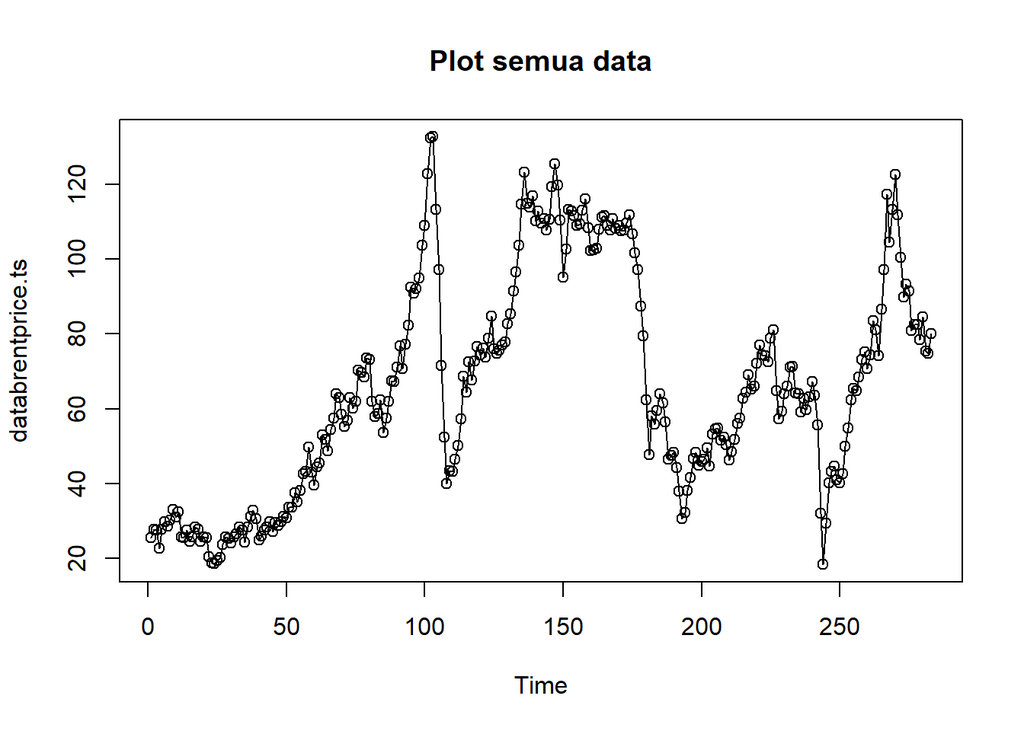

```r
#eksplorasi data
plot(databrentprice.ts, col="black",main="Plot semua data")
points(databrentprice.ts)
```

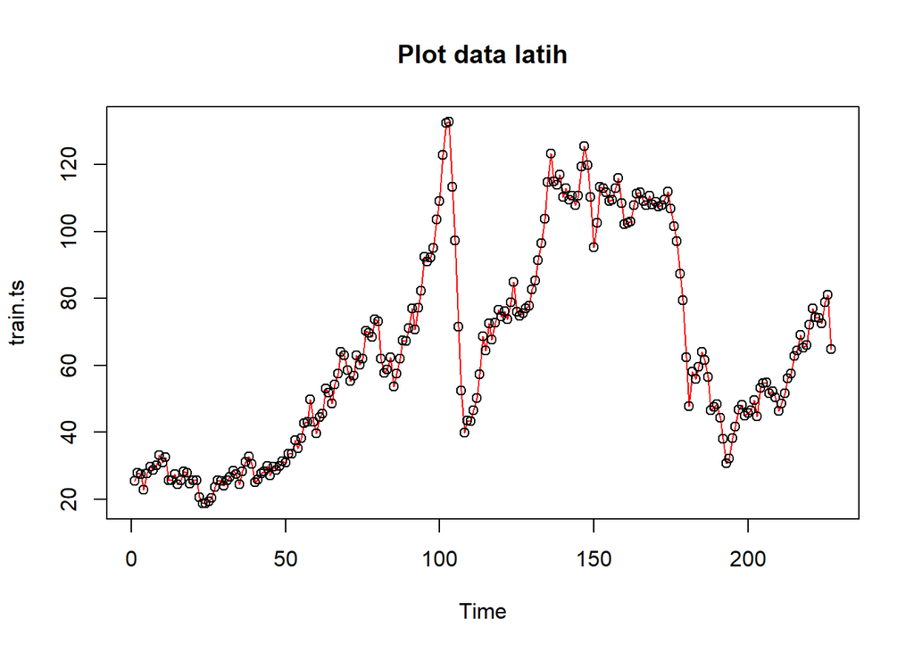

```r
plot(train.ts, col="red",main="Plot data latih")
points(train.ts)
```

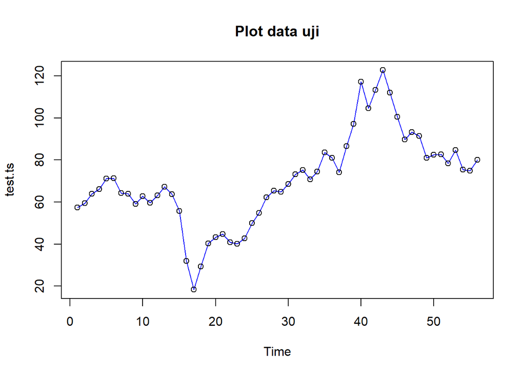

```r
plot(test.ts, col="blue",main="Plot data uji")
points(test.ts)
```

### SES

Single Exponential Smoothing merupakan metode pemulusan yang tepat digunakan untuk data dengan pola stasioner atau konstan.

Nilai pemulusan pada periode ke-t didapat dari persamaan:

$$\tilde{y}_T=\lambda y_t+(1-\lambda)\tilde{y}_{T-1}$$
Nilai parameter $\lambda$ adalah nilai antara 0 dan 1.

Nilai pemulusan periode ke-t bertindak sebagai nilai ramalan pada periode ke-$(T+\tau)$.

$$\tilde{y}_{T+\tau}(T)=\tilde{y}_T$$
Pemulusan dengan metode SES dapat dilakukan dengan dua fungsi dari *packages* berbeda, yaitu (1) fungsi `ses()` dari *packages* `forecast` dan (2) fungsi `HoltWinters` dari *packages* `stats` .

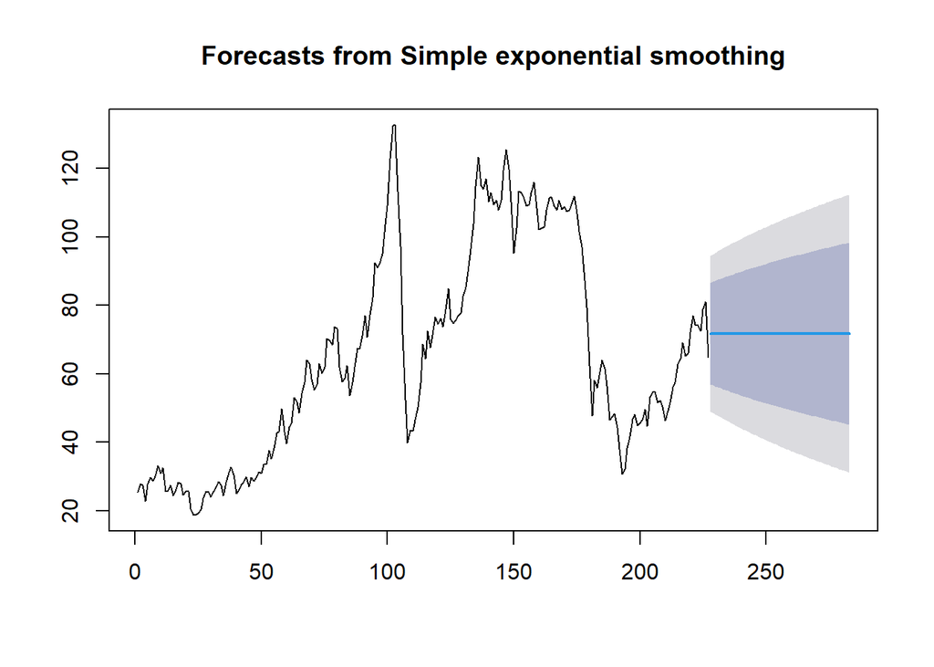

```r
#Cara 1 (fungsi ses)
ses.1 <- ses(train.ts, h = 56, alpha = 0.2)
plot(ses.1)
```

```r
ses.1
```

```
##     Point Forecast    Lo 80    Hi 80    Lo 95     Hi 95
## 228       71.76286 56.92909 86.59663 49.07657  94.44915
## 229       71.76286 56.63533 86.89039 48.62729  94.89843
## 230       71.76286 56.34716 87.17856 48.18658  95.33914
## 231       71.76286 56.06428 87.46144 47.75395  95.77177
## 232       71.76286 55.78640 87.73932 47.32898  96.19674
## 233       71.76286 55.51328 88.01244 46.91128  96.61444
## 234       71.76286 55.24468 88.28104 46.50048  97.02524
## 235       71.76286 54.98037 88.54535 46.09625  97.42947
## 236       71.76286 54.72016 88.80556 45.69830  97.82742
## 237       71.76286 54.46386 89.06186 45.30633  98.21939
## 238       71.76286 54.21131 89.31441 44.92008  98.60564
## 239       71.76286 53.96234 89.56338 44.53931  98.98641
## 240       71.76286 53.71680 89.80892 44.16380  99.36192
## 241       71.76286 53.47456 90.05116 43.79332  99.73240
```

[output cut: 42 more lines]

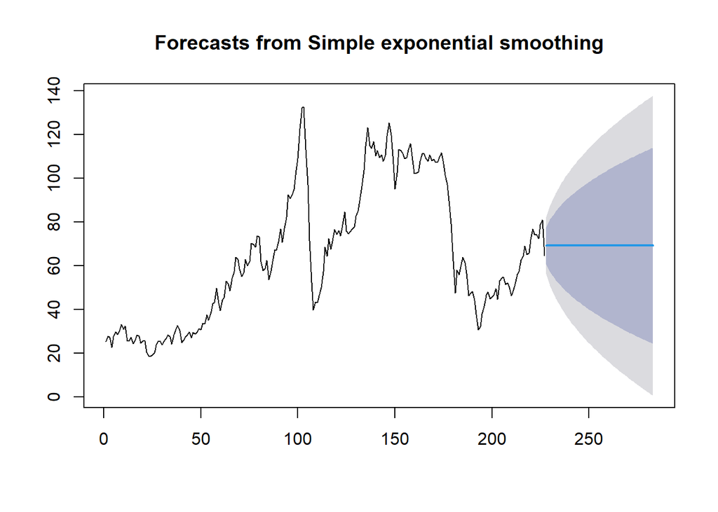

```r
ses.2<- ses(train.ts, h = 56, alpha = 0.7)
plot(ses.2)
```

```r
ses.2
```

```
##     Point Forecast    Lo 80     Hi 80      Lo 95     Hi 95
## 228       69.28441 60.81080  77.75801 56.3251501  82.24367
## 229       69.28441 58.94106  79.62776 53.4656177  85.10320
## 230       69.28441 57.36099  81.20782 51.0491157  87.51970
## 231       69.28441 55.96710  82.60172 48.9173355  89.65148
## 232       69.28441 54.70587  83.86295 46.9884577  91.58036
## 233       69.28441 53.54539  85.02343 45.2136548  93.35516
## 234       69.28441 52.46479  86.10403 43.5610156  95.00780
## 235       69.28441 51.44954  87.11928 42.0083255  96.56049
## 236       69.28441 50.48905  88.07977 40.5393834  98.02943
## 237       69.28441 49.57531  88.99351 39.1419430  99.42687
## 238       69.28441 48.70210  89.86672 37.8064800 100.76234
## 239       69.28441 47.86445  90.70436 36.5254136 102.04340
## 240       69.28441 47.05835  91.51046 35.2925932 103.27622
## 241       69.28441 46.28049  92.28833 34.1029465 104.46587
```

[output cut: 42 more lines]

Untuk mendapatkan gambar hasil pemulusan pada data latih dengan fungsi `ses()` , perlu digunakan fungsi `autoplot()` dan `autolayer()` dari *library packages* `ggplot2` .

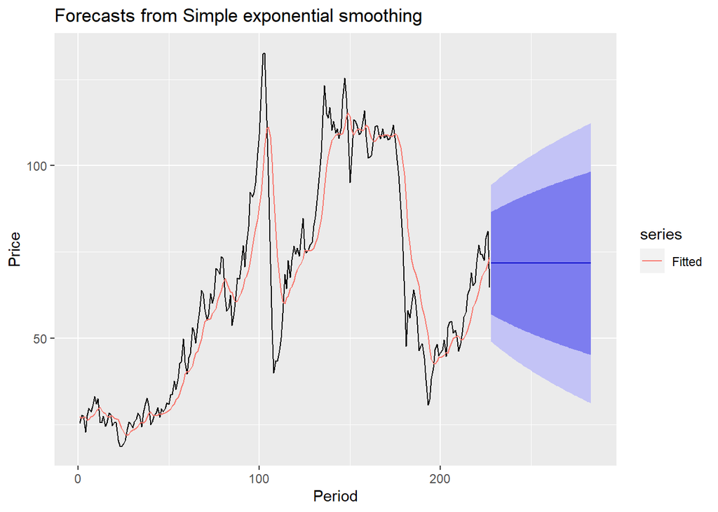

```r
library(ggplot2)
autoplot(ses.1) +
  autolayer(fitted(ses.1), series="Fitted") +
  ylab("Price") + xlab("Period")
```

Pada fungsi `ses()` , terdapat beberapa argumen yang umum digunakan, yaitu nilai `y` , `gamma` , `beta` , `alpha` , dan `h` .

Nilai `y` adalah nilai data deret waktu, `gamma` adalah parameter pemulusan untuk komponen musiman, `beta` adalah parameter pemulusan untuk tren, dan `alpha` adalah parameter pemulusan untuk stasioner, serta `h` adalah banyaknya periode yang akan diramalkan.

Kasus di atas merupakan contoh inisialisasi nilai parameter $\lambda$ dengan nilai `alpha` 0,2 dan 0,7 dan banyak periode data yang akan diramalkan adalah sebanyak 56 periode. Selanjutnya akan digunakan fungsi `HoltWinters()` dengan nilai inisialisasi parameter dan panjang periode peramalan yang sama dengan fungsi `ses()` .

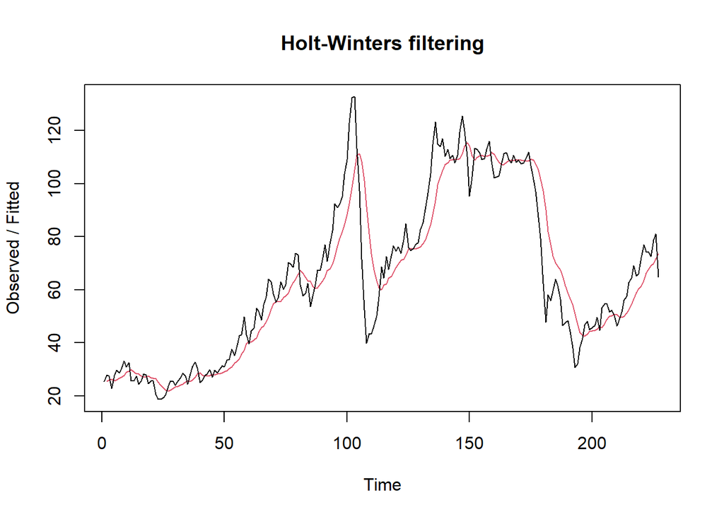

```r
#Cara 2 (fungsi Holtwinter)
ses1<- HoltWinters(train.ts, gamma = FALSE, beta = FALSE, alpha = 0.2)
plot(ses1)
```

```r
#ramalan
ramalan1<- forecast(ses1, h=56)
ramalan1
```

```
##     Point Forecast    Lo 80    Hi 80    Lo 95     Hi 95
## 228       71.76286 56.98540 86.54032 49.16269  94.36303
## 229       71.76286 56.69275 86.83297 48.71511  94.81061
## 230       71.76286 56.40567 87.12005 48.27607  95.24965
## 231       71.76286 56.12387 87.40185 47.84508  95.68064
## 232       71.76286 55.84705 87.67867 47.42173  96.10399
## 233       71.76286 55.57496 87.95076 47.00561  96.52011
## 234       71.76286 55.30738 88.21834 46.59637  96.92935
## 235       71.76286 55.04407 88.48165 46.19368  97.33204
## 236       71.76286 54.78485 88.74087 45.79724  97.72848
## 237       71.76286 54.52953 88.99619 45.40675  98.11897
## 238       71.76286 54.27793 89.24779 45.02197  98.50375
## 239       71.76286 54.02991 89.49581 44.64265  98.88307
## 240       71.76286 53.78530 89.74042 44.26856  99.25716
## 241       71.76286 53.54398 89.98174 43.89949  99.62623
```

[output cut: 42 more lines]

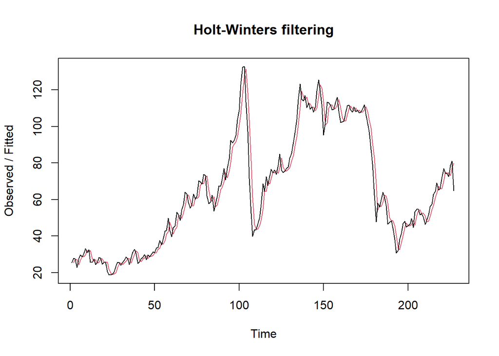

```r
ses2<- HoltWinters(train.ts, gamma = FALSE, beta = FALSE, alpha = 0.7)
plot(ses2)
```

```r
#ramalan
ramalan2<- forecast(ses2, h=56)
ramalan2
```

```
##     Point Forecast    Lo 80     Hi 80      Lo 95     Hi 95
## 228       69.28441 60.81811  77.75071 56.3363162  82.23250
## 229       69.28441 58.94997  79.61885 53.4792477  85.08957
## 230       69.28441 57.37126  81.19755 51.0648278  87.50399
## 231       69.28441 55.97857  82.59025 48.9348844  89.63393
## 232       69.28441 54.71843  83.85038 47.0076686  91.56115
## 233       69.28441 53.55895  85.00987 45.2343949  93.33442
## 234       69.28441 52.47928  86.08954 43.5831796  94.98564
## 235       69.28441 51.46490  87.10391 42.0318274  96.53699
## 236       69.28441 50.50524  88.06357 40.5641511  98.00466
## 237       69.28441 49.59229  88.97652 39.1679147  99.40090
## 238       69.28441 48.71983  89.84898 37.8336023 100.73521
## 239       69.28441 47.88291  90.68591 36.5536398 102.01518
## 240       69.28441 47.07751  91.49131 35.3218817 103.24693
## 241       69.28441 46.30031  92.26851 34.1332600 104.43556
```

[output cut: 42 more lines]

Nilai parameter $\alpha$ dari kedua fungsi dapat dioptimalkan menyesuaikan dari *error*-nya paling minimumnya. Caranya adalah dengan membuat parameter $\alpha =$ `NULL` .

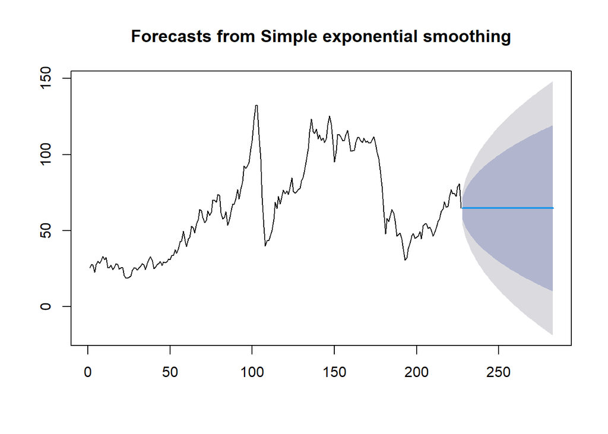

```r
#SES
ses.opt <- ses(train.ts, h = 56, alpha = NULL)
plot(ses.opt)
```

```r
ses.opt
```

```
##     Point Forecast    Lo 80     Hi 80       Lo 95     Hi 95
## 228       64.75163 57.45972  72.04353  53.5996237  75.90363
## 229       64.75163 54.43983  75.06342  48.9811009  80.52216
## 230       64.75163 52.12252  77.38073  45.4370778  84.06618
## 231       64.75163 50.16891  79.33434  42.4492923  87.05396
## 232       64.75163 48.44774  81.05552  39.8169833  89.68627
## 233       64.75163 46.89167  82.61158  37.4371844  92.06607
## 234       64.75163 45.46072  84.04254  35.2487272  94.25453
## 235       64.75163 44.12881  85.37444  33.2117567  96.29150
## 236       64.75163 42.87786  86.62539  31.2985891  98.20467
## 237       64.75163 41.69468  87.80858  29.4890680 100.01419
## 238       64.75163 40.56932  88.93394  27.7679767 101.73528
## 239       64.75163 39.49405  90.00921  26.1234933 103.37976
## 240       64.75163 38.46272  91.04053  24.5462164 104.95704
## 241       64.75163 37.47036  92.03290  23.0285235 106.47473
```

[output cut: 42 more lines]

```r
#Lamda Optimum Holt Winter
sesopt<- HoltWinters(train.ts, gamma = FALSE, beta = FALSE,alpha = NULL)
sesopt
```

```
## Holt-Winters exponential smoothing without trend and without seasonal component.
##
## Call:
## HoltWinters(x = train.ts, alpha = NULL, beta = FALSE, gamma = FALSE)
##
## Smoothing parameters:
##  alpha: 0.999958
##  beta : FALSE
##  gamma: FALSE
##
## Coefficients:
##       [,1]
## a 64.75068
```

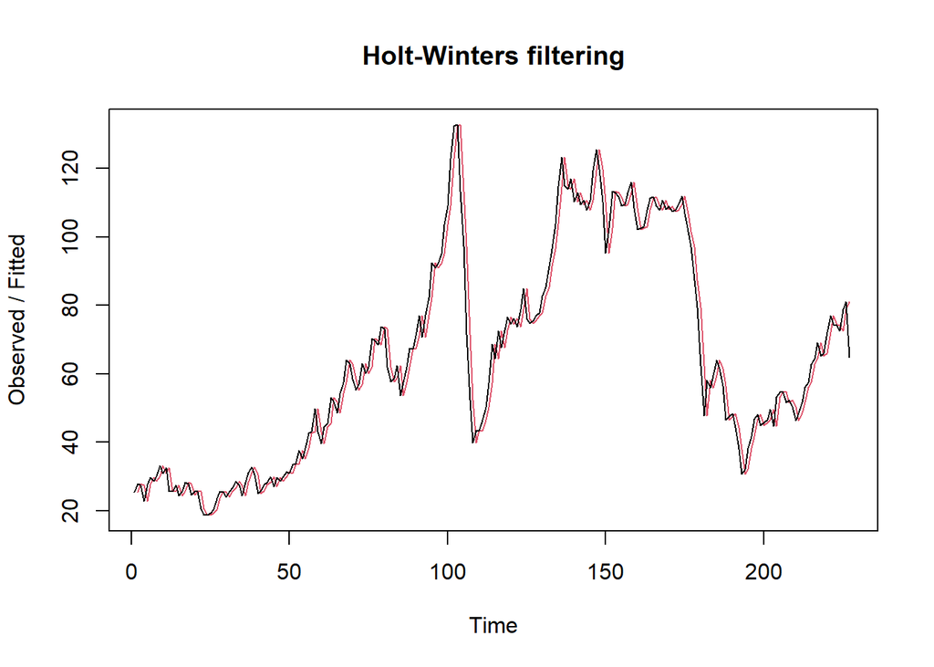

```r
plot(sesopt)
```

```r
#ramalan
ramalanopt<- forecast(sesopt, h=56)
ramalanopt
```

```
##     Point Forecast    Lo 80     Hi 80       Lo 95     Hi 95
## 228       64.75068 57.46234  72.03903  53.6041220  75.89725
## 229       64.75068 54.44362  75.05774  48.9873960  80.51397
## 230       64.75068 52.12725  77.37411  45.4448130  84.05656
## 231       64.75068 50.17445  79.32692  42.4582625  87.04311
## 232       64.75068 48.45400  81.04737  39.8270514  89.67432
## 233       64.75068 46.89858  82.60279  37.4482506  92.05312
## 234       64.75068 45.46823  84.03314  35.2607150  94.24065
## 235       64.75068 44.13689  85.36448  33.2246047  96.27676
## 236       64.75068 42.88647  86.61490  31.3122468  98.18912
## 237       64.75068 41.70378  87.79758  29.5034928  99.99788
## 238       64.75068 40.57890  88.92247  27.7831321 101.71824
## 239       64.75068 39.50409  89.99728  26.1393476 103.36202
## 240       64.75068 38.47320  91.02817  24.5627418 104.93863
## 241       64.75068 37.48126  92.02011  23.0456950 106.45567
```

[output cut: 42 more lines]

Setelah dilakukan peramalan, akan dilakukan perhitungan keakuratan hasil peramalan. Perhitungan akurasi ini dilakukan baik pada data latih dan data uji.

#### Akurasi Data Latih

Perhitungan akurasi data dapat dilakukan dengan cara langsung maupun manual. Secara langsung, nilai akurasi dapat diambil dari objek yang tersimpan pada hasil SES, yaitu *sum of squared errors* (SSE). Nilai akurasi lain dapat dihitung pula dari nilai SSE tersebut.

```r
#Keakuratan Metode
#Pada data training
SSE1<-ses1$SSE
MSE1<-ses1$SSE/length(train.ts)
RMSE1<-sqrt(MSE1)

akurasi1 <- matrix(c(SSE1,MSE1,RMSE1))
row.names(akurasi1)<- c("SSE", "MSE", "RMSE")
colnames(akurasi1) <- c("Akurasi lamda=0.2")
akurasi1
```

```
##      Akurasi lamda=0.2
## SSE        30153.09075
## MSE          132.83300
## RMSE          11.52532
```

```r
SSE2<-ses2$SSE
MSE2<-ses2$SSE/length(train.ts)
RMSE2<-sqrt(MSE2)

akurasi2 <- matrix(c(SSE2,MSE2,RMSE2))
row.names(akurasi2)<- c("SSE", "MSE", "RMSE")
colnames(akurasi2) <- c("Akurasi lamda=0.7")
akurasi2
```

```
##      Akurasi lamda=0.7
## SSE        9836.995720
## MSE          43.334783
## RMSE          6.582916
```

```r
#Cara Manual
fitted1<-ramalan1$fitted
sisaan1<-ramalan1$residuals
head(sisaan1)
```

```
## Time Series:
## Start = 1
## End = 6
## Frequency = 1
## [1]        NA  2.270000  1.526000 -3.509200  2.172640  3.798112
```

```r
resid1<-training$Price-ramalan1$fitted
head(resid1)
```

```
## Time Series:
## Start = 1
## End = 6
## Frequency = 1
## [1]        NA  2.270000  1.526000 -3.509200  2.172640  3.798112
```

```r
#Cara Manual
SSE.1=sum(sisaan1[2:length(train.ts)]^2)
SSE.1
```

```
## [1] 30153.09
```

```r
MSE.1 = SSE.1/length(train.ts)
MSE.1
```

```
## [1] 132.833
```

```r
MAPE.1 = sum(abs(sisaan1[2:length(train.ts)]/train.ts[2:length(train.ts)])*
               100)/length(train.ts)
MAPE.1
```

```
## [1] 13.22994
```

```r
akurasi.1 <- matrix(c(SSE.1,MSE.1,MAPE.1))
row.names(akurasi.1)<- c("SSE", "MSE", "MAPE")
colnames(akurasi.1) <- c("Akurasi lamda=0.2")
akurasi.1
```

```
##      Akurasi lamda=0.2
## SSE        30153.09075
## MSE          132.83300
## MAPE          13.22994
```

```r
fitted2<-ramalan2$fitted
sisaan2<-ramalan2$residuals
head(sisaan2)
```

```
## Time Series:
## Start = 1
## End = 6
## Frequency = 1
## [1]        NA  2.270000  0.391000 -4.612700  3.596190  3.138857
```

```r
resid2<-training$Price-ramalan2$fitted
head(resid2)
```

```
## Time Series:
## Start = 1
## End = 6
## Frequency = 1
## [1]        NA  2.270000  0.391000 -4.612700  3.596190  3.138857
```

```r
SSE.2=sum(sisaan2[2:length(train.ts)]^2)
SSE.2
```

```
## [1] 9836.996
```

```r
MSE.2 = SSE.2/length(train.ts)
MSE.2
```

```
## [1] 43.33478
```

```r
MAPE.2 = sum(abs(sisaan2[2:length(train.ts)]/train.ts[2:length(train.ts)])*
               100)/length(train.ts)
MAPE.2
```

```
## [1] 7.636378
```

```r
akurasi.2 <- matrix(c(SSE.2,MSE.2,MAPE.2))
row.names(akurasi.2)<- c("SSE", "MSE", "MAPE")
colnames(akurasi.2) <- c("Akurasi lamda=0.7")
akurasi.2
```

```
##      Akurasi lamda=0.7
## SSE        9836.995720
## MSE          43.334783
## MAPE          7.636378
```

## Perbandingan akurasi lamda = 0.2 dan lamda = 0.7

```r
perbandingan <- cbind(akurasi.1, akurasi.2)
perbandingan
```

```
##      Akurasi lamda=0.2 Akurasi lamda=0.7
## SSE        30153.09075       9836.995720
## MSE          132.83300         43.334783
## MAPE          13.22994          7.636378
```

Berdasarkan nilai SSE, MSE, RMSE, dan MAPE di antara kedua parameter, nilai parameter $\lambda=0,7$ menghasilkan akurasi yang lebih baik dibanding $\lambda=0,2$ . Hal ini dilihat dari nilai masing-masing ukuran akurasi yang lebih kecil. Berdasarkan nilai MAPE-nya, hasil ini dapat dikategorikan sebagai peramalan sangat baik.

#### Akurasi Data Uji

Akurasi data uji dapat dihitung dengan cara yang hampir sama dengan perhitungan akurasi data latih.

```r
selisih1<-ramalan1$mean-testing$Price
SSEtesting1<-sum(selisih1^2)
MSEtesting1<-SSEtesting1/length(testing)

selisih2<-ramalan2$mean-testing$Price
SSEtesting2<-sum(selisih2^2)
MSEtesting2<-SSEtesting2/length(testing)

selisihopt<-ramalanopt$mean-testing$Price
SSEtestingopt<-sum(selisihopt^2)
MSEtestingopt<-SSEtestingopt/length(testing)
```

```r
akurasitesting1 <- matrix(c(SSEtesting1,SSEtesting2,SSEtestingopt))
row.names(akurasitesting1)<- c("SSE1", "SSE2", "SSEopt")
akurasitesting1
```

```
##            [,1]
## SSE1   26699.61
## SSE2   26687.16
## SSEopt 28444.68
```

```r
akurasitesting2 <- matrix(c(MSEtesting1,MSEtesting2,MSEtestingopt))
row.names(akurasitesting2)<- c("MSE1", "MSE2", "MSEopt")
akurasitesting2
```

```
##            [,1]
## MSE1   13349.81
## MSE2   13343.58
## MSEopt 14222.34
```

Selain dengan cara di atas, perhitungan nilai akurasi dapat menggunakan fungsi `accuracy()` dari *package* `forecast` . Penggunaannya yaitu dengan menuliskan `accuracy(hasil ramalan, kondisi aktual)` . Contohnya adalah sebagai berikut.

```r
#cara lain
accuracy(ramalanopt,testing$Price)
```

```
##                     ME      RMSE       MAE         MPE      MAPE     MASE
## Training set 0.1736386  5.677186  4.137191 -0.01944753  7.095183 1.000005
## Test set     5.7280659 22.537538 17.065414 -4.27120256 28.582910 4.124902
##                   ACF1
## Training set 0.3467607
## Test set            NA
```

### DES

Metode pemulusan *Double Exponential Smoothing* (DES) digunakan untuk data yang memiliki pola tren. Metode DES adalah metode semacam SES, hanya saja dilakukan dua kali, yaitu pertama untuk tahapan ‘level’ dan kedua untuk tahapan ‘tren’. Pemulusan menggunakan metode ini akan menghasilkan peramalan tidak konstan untuk periode berikutnya.

Pemulusan dengan metode DES kali ini akan menggunakan fungsi `HoltWinters()` . Jika sebelumnya nilai argumen `beta` dibuat `FALSE` , kali ini argumen tersebut akan diinisialisasi bersamaan dengan nilai `alpha` .

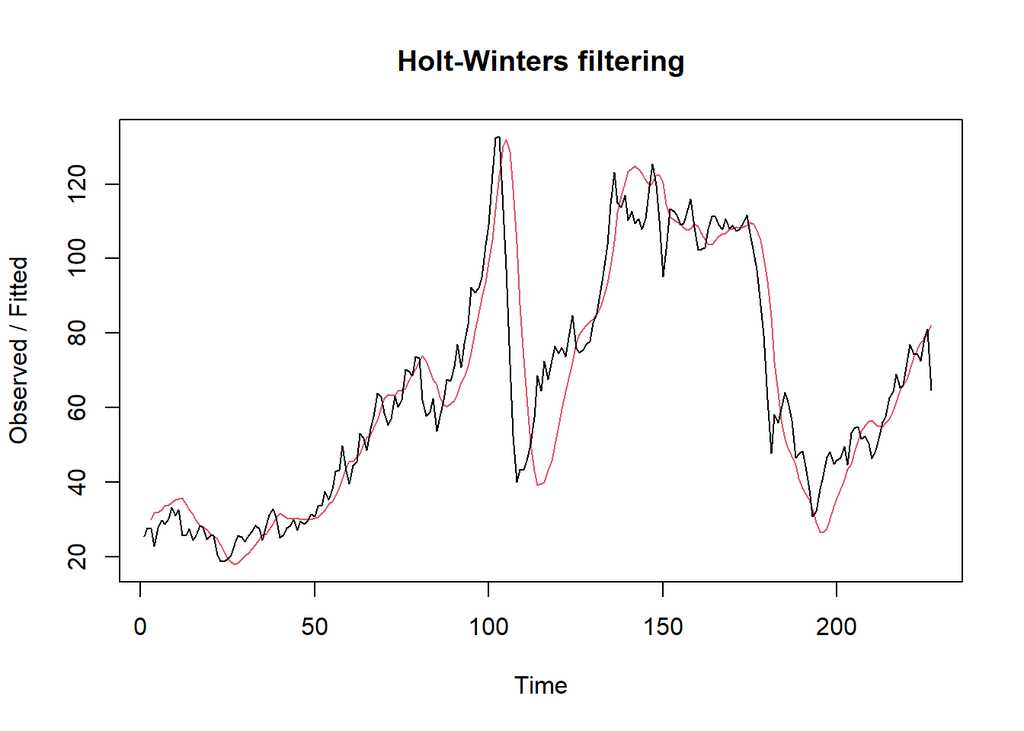

```r
#Lamda=0.2 dan gamma=0.2
des.1<- HoltWinters(train.ts, gamma = FALSE, beta = 0.2, alpha = 0.2)
plot(des.1)
```

```r
#ramalan
ramalandes1<- forecast(des.1, h=56)
ramalandes1
```

```
##     Point Forecast       Lo 80     Hi 80       Lo 95    Hi 95
## 228       79.79648  63.5380539  96.05491   54.931362 104.6616
## 229       80.92647  64.2063498  97.64658   55.355255 106.4977
## 230       82.05645  64.7276795  99.38522   55.554383 108.5585
## 231       83.18643  65.0934971 101.27937   55.515676 110.8572
## 232       84.31642  65.3003090 103.33252   55.233790 113.3990
## 233       85.44640  65.3489826 105.54382   54.710053 116.1827
## 234       86.57638  65.2437386 107.90903   53.950919 119.2018
## 235       87.70637  64.9910666 110.42167   52.966314 122.4464
## 236       88.83635  64.5987462 113.07395   51.768134 125.9046
## 237       89.96633  64.0750730 115.85759   50.369068 129.5636
## 238       91.09632  63.4283118 118.76432   48.781755 133.4109
## 239       92.22630  62.6663488 121.78625   47.018256 137.4343
## 240       93.35628  61.7965003 124.91607   45.089760 141.6228
## 241       94.48627  60.8254298 128.14710   43.006459 145.9661
```

[output cut: 42 more lines]

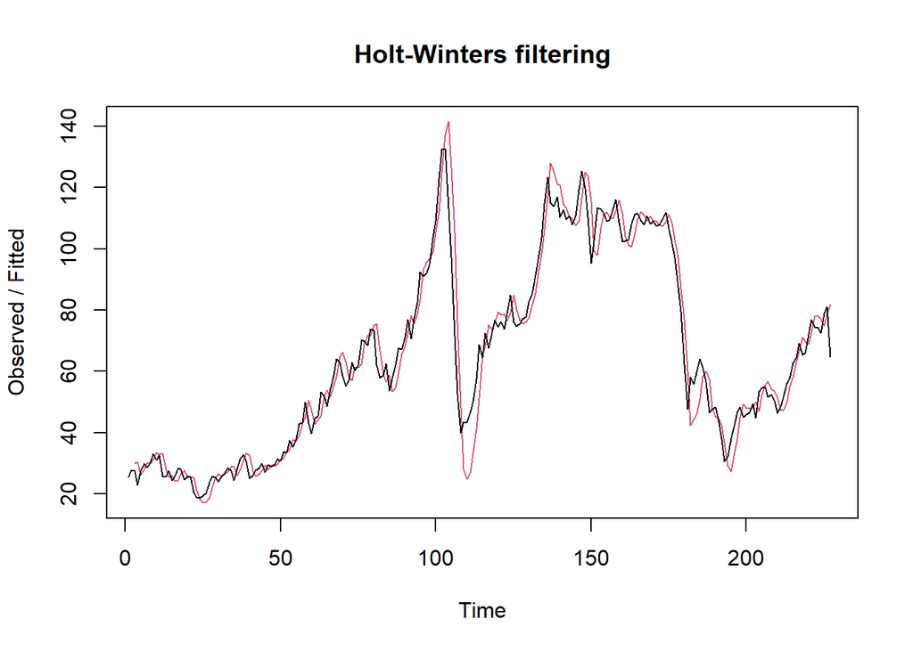

```r
#Lamda=0.6 dan gamma=0.3
des.2<- HoltWinters(train.ts, gamma = FALSE, beta = 0.3, alpha = 0.6)
plot(des.2)
```

```r
#ramalan
ramalandes2<- forecast(des.2, h=56)
ramalandes2
```

```
##     Point Forecast        Lo 80     Hi 80       Lo 95     Hi 95
## 228     70.2247558   60.8306578  79.61885   55.857723  84.59179
## 229     68.8849768   56.9711270  80.79883   50.664316  87.10564
## 230     67.5451977   52.6029701  82.48743   44.693033  90.39736
## 231     66.2054187   47.8217665  84.58907   38.090049  94.32079
## 232     64.8656397   42.6907921  87.04049   30.952137  98.77914
## 233     63.5258606   37.2525988  89.79912   23.344374 103.70735
## 234     62.1860816   31.5371259  92.83504   15.312549 109.05961
## 235     60.8463025   25.5664925  96.12611    6.890489 114.80212
## 236     59.5065235   19.3577706  99.65528   -1.895695 120.90874
## 237     58.1667445   12.9246279 103.40886  -11.025102 127.35859
## 238     56.8269654    6.2783373 107.37559  -20.480490 134.13442
## 239     55.4871864   -0.5715771 111.54595  -30.247294 141.22167
## 240     54.1474073   -7.6169120 115.91173  -40.312968 148.60778
## 241     52.8076283  -14.8504893 120.46575  -50.666533 156.28179
```

[output cut: 42 more lines]

Selanjutnya jika ingin membandingkan plot data latih dan data uji adalah sebagai berikut.

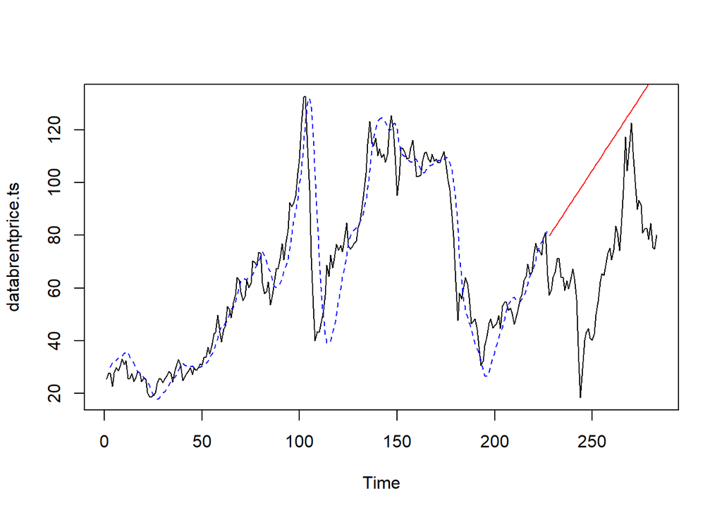

```r
#Visually evaluate the prediction
plot(databrentprice.ts)
lines(des.1$fitted[,1], lty=2, col="blue")
lines(ramalandes1$mean, col="red")
```

Untuk mendapatkan nilai parameter optimum dari DES, argumen `alpha` dan `beta` dapat dibuat `NULL` seperti berikut.

```r
#Lamda dan gamma optimum
des.opt<- HoltWinters(train.ts, gamma = FALSE)
des.opt
```

```
## Holt-Winters exponential smoothing with trend and without seasonal component.
##
## Call:
## HoltWinters(x = train.ts, gamma = FALSE)
##
## Smoothing parameters:
##  alpha: 1
##  beta : 0.02306282
##  gamma: FALSE
##
## Coefficients:
##         [,1]
## a 64.7500000
## b -0.1025904
```

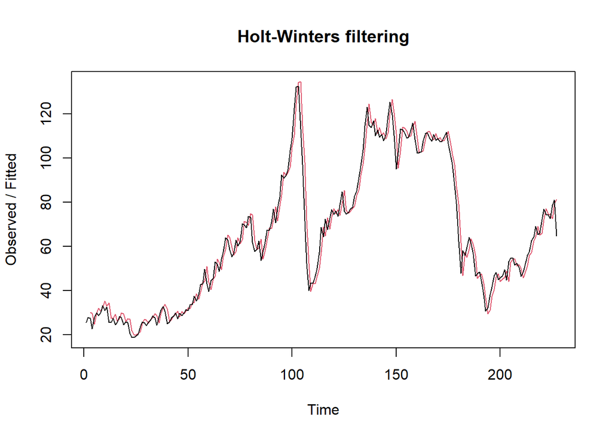

```r
plot(des.opt)
```

```r
#ramalan
ramalandesopt<- forecast(des.opt, h=56)
ramalandesopt
```

```
##     Point Forecast       Lo 80     Hi 80       Lo 95     Hi 95
## 228       64.64741  57.2740625  72.02076  53.3708484  75.92397
## 229       64.54482  53.9964028  75.09324  48.4124085  80.67723
## 230       64.44223  51.3744685  77.50999  44.4568141  84.42764
## 231       64.33964  49.0780561  79.60122  40.9990625  87.68021
## 232       64.23705  46.9808745  81.49322  37.8460081  90.62809
## 233       64.13446  45.0189381  83.24998  34.8997933  93.36912
## 234       64.03187  43.1546927  84.90904  32.1029842  95.96075
## 235       63.92928  41.3639640  86.49459  29.4186091  98.43994
## 236       63.82669  39.6301639  88.02321  26.8212987 100.83207
## 237       63.72410  37.9413628  89.50683  24.2928084 103.15538
## 238       63.62151  36.2886671  90.95434  21.8195365 105.42347
## 239       63.51891  34.6652546  92.37258  19.3910496 107.64678
## 240       63.41632  33.0657702  93.76688  16.9991573 109.83349
## 241       63.31373  31.4859289  95.14154  14.6373066 111.99016
```

[output cut: 42 more lines]

Selanjutnya akan dilakukan perhitungan akurasi pada data latih maupun data uji dengan ukuran akurasi SSE, MSE dan MAPE.

#### Akurasi Data Latih

```r
#Akurasi Data Training
ssedes.train1<-des.1$SSE
msedes.train1<-ssedes.train1/length(train.ts)
sisaandes1<-ramalandes1$residuals
head(sisaandes1)
```

```
## Time Series:
## Start = 1
## End = 6
## Frequency = 1
## [1]        NA        NA -2.560000 -8.945600 -3.986256 -2.779331
```

```r
mapedes.train1 <- sum(abs(sisaandes1[3:length(train.ts)]/train.ts[3:length(train.ts)])
                      *100)/length(train.ts)

akurasides.1 <- matrix(c(ssedes.train1,msedes.train1,mapedes.train1))
row.names(akurasides.1)<- c("SSE", "MSE", "MAPE")
colnames(akurasides.1) <- c("Akurasi lamda=0.2 dan gamma=0.2")
akurasides.1
```

```
##      Akurasi lamda=0.2 dan gamma=0.2
## SSE                       36055.9091
## MSE                         158.8366
## MAPE                         13.9730
```

```r
ssedes.train2<-des.2$SSE
msedes.train2<-ssedes.train2/length(train.ts)
sisaandes2<-ramalandes2$residuals
head(sisaandes2)
```

```
## Time Series:
## Start = 1
## End = 6
## Frequency = 1
## [1]        NA        NA -2.560000 -7.563200  1.506896  1.943693
```

```r
mapedes.train2 <- sum(abs(sisaandes2[3:length(train.ts)]/train.ts[3:length(train.ts)])
                      *100)/length(train.ts)

akurasides.2 <- matrix(c(ssedes.train2,msedes.train2,mapedes.train2))
row.names(akurasides.2)<- c("SSE", "MSE", "MAPE")
colnames(akurasides.2) <- c("Akurasi lamda=0.6 dan gamma=0.3")
akurasides.2
```

```
##      Akurasi lamda=0.6 dan gamma=0.3
## SSE                     12037.894002
## MSE                        53.030370
## MAPE                        8.733324
```

#### Akurasi Data Uji

```r
#Akurasi Data Testing
selisihdes1<-ramalandes1$mean-testing$Price
selisihdes1
```

```
## Time Series:
## Start = 228
## End = 283
## Frequency = 1
##  [1] 22.436482 21.516466 18.096449 17.046432 13.086416 14.126399 22.356383
##  [8] 23.786366 29.796349 27.136333 31.386316 29.016300 26.046283 30.836266
## [15] 39.956250 64.736233 79.496217 69.626200 59.866184 58.026167 57.656150
## [22] 62.616134 64.466117 63.096101 56.926084 53.276067 46.896051 44.896034
## [29] 46.626018 44.036001 40.535984 39.655968 45.205951 42.595935 34.675918
## [36] 38.295901 46.305885 35.095868 25.605852  6.615835 20.415819 12.785802
## [43]  4.545785 16.455769 29.065752 40.885736 38.445719 41.485702 53.115686
## [50] 52.665669 53.705653 58.995636 53.915619 64.215603 65.975586 61.835570
```

```r
SSEtestingdes1<-sum(selisihdes1^2)
MSEtestingdes1<-SSEtestingdes1/length(testing$Price)
MAPEtestingdes1<-sum(abs(selisihdes1/testing$Price)*100)/length(testing$Price)

selisihdes2<-ramalandes2$mean-testing$Price
selisihdes2
```

```
## Time Series:
## Start = 228
## End = 283
## Frequency = 1
##  [1]   12.86475581    9.47497677    3.58519773    0.06541869   -6.36436035
##  [6]   -7.79413939   -2.03391842   -3.07369746    0.46652350   -4.66325554
## [11]   -2.88303458   -7.72281362  -13.16259266  -10.84237170   -4.19215074
## [16]   18.11807022   30.40829118   18.06851214    5.83873310    1.52895406
## [21]   -1.31082498    1.17939598    0.55961694   -3.28016210  -11.91994114
## [26]  -18.03972018  -26.88949922  -31.35927826  -32.09905730  -37.15883634
## [31]  -43.12861538  -46.47839442  -43.39817346  -48.47795250  -58.86773154
## [36]  -57.71751058  -52.17728962  -65.85706866  -77.81684770  -99.27662674
## [41]  -87.94640578  -98.04618482 -108.75596386  -99.31574290  -89.17552194
## [46]  -79.82530098  -84.73508002  -84.16485906  -75.00463810  -77.92441714
## [51]  -79.35419618  -76.53397522  -84.08375426  -76.25353330  -76.96331234
## [56]  -83.57309138
```

```r
SSEtestingdes2<-sum(selisihdes2^2)
MSEtestingdes2<-SSEtestingdes2/length(testing$Price)
MAPEtestingdes2<-sum(abs(selisihdes2/testing$Price)*100)/length(testing$Price)

selisihdesopt<-ramalandesopt$mean-testing$Price
selisihdesopt
```

```
## Time Series:
## Start = 228
## End = 283
## Frequency = 1
##  [1]   7.287409572   5.134819144   0.482228716  -1.800361712  -6.992952140
##  [6]  -7.185542568  -0.188132996   0.009276576   4.786686147   0.894095719
## [11]   3.911505291   0.308914863  -3.893675565  -0.336265993   7.551143579
## [16]  31.098553151  44.625962723  33.523372295  22.530781867  19.458191439
## [21]  17.855601011  21.583010583  22.200420155  19.597829727  12.195239299
## [26]   7.312648870  -0.299941558  -3.532531986  -3.035122414  -6.857712842
## [31] -11.590303270 -13.702893698  -9.385484126 -13.228074554 -22.380664982
## [36] -19.993255410 -13.215845838 -25.658436266 -36.381026694 -56.603617122
## [41] -44.036207550 -52.898797978 -62.371388407 -51.693978835 -40.316569263
## [46] -29.729159691 -33.401750119 -31.594340547 -21.196930975 -22.879521403
## [51] -23.072111831 -19.014702259 -25.327292687 -16.259883115 -15.732473543
## [56] -21.105063971
```

```r
SSEtestingdesopt<-sum(selisihdesopt^2)
MSEtestingdesopt<-SSEtestingdesopt/length(testing$Price)
MAPEtestingdesopt<-sum(abs(selisihdesopt/testing$Price)*100)/length(testing$Price)

akurasitestingdes <-
  matrix(c(SSEtestingdes1,MSEtestingdes1,MAPEtestingdes1,SSEtestingdes2,MSEtestingdes2,
           MAPEtestingdes2,SSEtestingdesopt,MSEtestingdesopt,MAPEtestingdesopt),
         nrow=3,ncol=3)
row.names(akurasitestingdes)<- c("SSE", "MSE", "MAPE")
colnames(akurasitestingdes) <- c("des ske1","des ske2","des opt")
akurasitestingdes
```

```
##          des ske1     des ske2     des opt
## SSE  109368.22341 162290.01774 33431.04667
## MSE    1953.00399   2898.03603   596.98298
## MAPE     72.74639     51.90056    29.86983
```

#### Perbandingan SES dan DES

```r
MSEfull <-
  matrix(c(MSEtesting1,MSEtesting2,MSEtestingopt,MSEtestingdes1,MSEtestingdes2,
           MSEtestingdesopt),nrow=3,ncol=2)
row.names(MSEfull)<- c("ske 1", "ske 2", "ske opt")
colnames(MSEfull) <- c("ses","des")
MSEfull
```

```
##              ses      des
## ske 1   13349.81 1953.004
## ske 2   13343.58 2898.036
## ske opt 14222.34  596.983
```